# CM3015 MLNN - Final

### Reduce batch size

So far, we have specifically been working with batch size 512, lets see if we can get some more favorable results be decreasing the batch size number.

We will set the network size to a static net_b (16-8-4-1), and use i to run sequentially larger the batch sizes.

```python
histories = {}
model.reset_states()
## use i to run different batch sizes, adding batch size to end of model name
for i in [64, 128, 256, 512, 1024]:
    model = build_model(16, 8, 4 , 1)
    model_name = str(16) + '-' + str(8) + '-' + str(4) + '-' + str(1) + '-|' + str(i)
    print('Training', model_name)
    history = model.fit(partial_x_train,
                       partial_y_train,
                        epochs=50,
                        batch_size=i,
                        validation_data=(x_val, y_val),
                        verbose = 0,
                        callbacks = [CustomCallback()])
    histories[model_name] = history
    model.summary()
```

```
Training 16-8-4-1-|64
Model: "sequential_86"
_________________________________________________________________
 Layer (type)                Output Shape              Param #
=================================================================
 dense_337 (Dense)           (None, 16)                160016

 dropout_225 (Dropout)       (None, 16)                0

 dense_338 (Dense)           (None, 8)                 136

 dropout_226 (Dropout)       (None, 8)                 0

 dense_339 (Dense)           (None, 4)                 36

 dropout_227 (Dropout)       (None, 4)                 0

 dense_340 (Dense)           (None, 1)                 5

=================================================================
Total params: 160193 (625.75 KB)
Trainable params: 160193 (625.75 KB)
Non-trainable params: 0 (0.00 Byte)
_________________________________________________________________
Training 16-8-4-1-|128
Model: "sequential_87"
_________________________________________________________________
 Layer (type)                Output Shape              Param #
=================================================================
 dense_341 (Dense)           (None, 16)                160016

 dropout_228 (Dropout)       (None, 16)                0

 dense_342 (Dense)           (None, 8)                 136

 dropout_229 (Dropout)       (None, 8)                 0

 dense_343 (Dense)           (None, 4)                 36

 dropout_230 (Dropout)       (None, 4)                 0
```

[output cut: 65 more lines]

```
 dense_354 (Dense)           (None, 8)                 136

 dropout_238 (Dropout)       (None, 8)                 0

 dense_355 (Dense)           (None, 4)                 36

 dropout_239 (Dropout)       (None, 4)                 0

 dense_356 (Dense)           (None, 1)                 5

=================================================================
Total params: 160193 (625.75 KB)
Trainable params: 160193 (625.75 KB)
Non-trainable params: 0 (0.00 Byte)
_________________________________________________________________
```

```python
history_dict = history.history
history_dict.keys()
```

```
dict_keys(['loss', 'accuracy', 'val_loss', 'val_accuracy'])
```

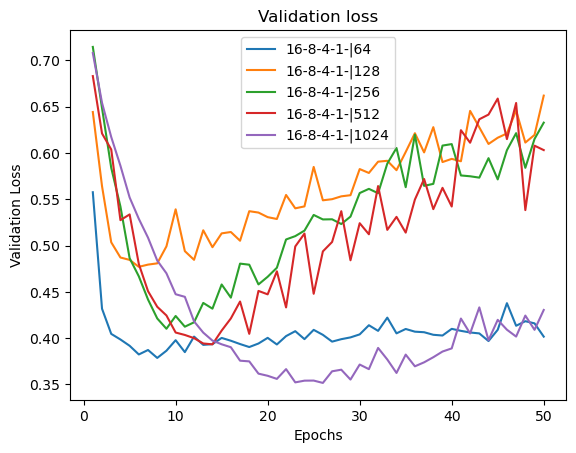

```python
#declare networks according to "histories[model_name]"
net_a, net_b, net_c, net_d, net_e = '16-8-4-1-|64', '16-8-4-1-|128', '16-8-4-1-|256', '16-8-4-1-|512', '16-8-4-1-|1024'
#plotting validation loss
plot_loss_comparison(loss_a=histories[net_a].history['val_loss'], label_a=net_a,
                     loss_b=histories[net_b].history['val_loss'], label_b=net_b,
                     loss_c=histories[net_c].history['val_loss'], label_c=net_c,
                     loss_d=histories[net_d].history['val_loss'], label_d=net_d,
                     loss_e=histories[net_e].history['val_loss'], label_e=net_e,
                        y_label='Validation Loss')
```

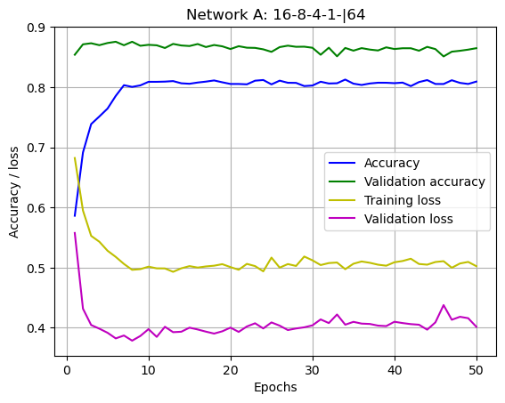

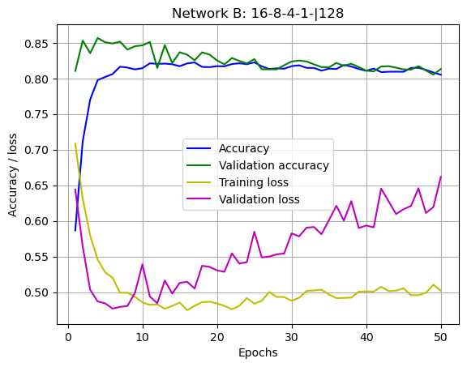

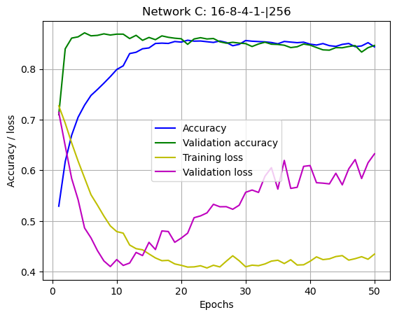

```python
plot_net_a(acc=histories[net_a].history['accuracy'], label_a="Accuracy",
           val_acc=histories[net_a].history['val_accuracy'], label_b="Validation accuracy",
            tloss=histories[net_a].history['loss'], label_c="Training loss",
            loss=histories[net_a].history['val_loss'], label_d="Validation loss", y_label='Accuracy / loss')
plot_net_b(acc=histories[net_b].history['accuracy'], label_a="Accuracy",
           val_acc=histories[net_b].history['val_accuracy'], label_b="Validation accuracy",
            tloss=histories[net_b].history['loss'], label_c="Training loss",
            loss=histories[net_b].history['val_loss'], label_d="Validation loss", y_label='Accuracy / loss')
plot_net_c(acc=histories[net_c].history['accuracy'], label_a="Accuracy",
            val_acc=histories[net_c].history['val_accuracy'], label_b="Validation accuracy",
            tloss=histories[net_c].history['loss'], label_c="Training loss",
            loss=histories[net_c].history['val_loss'], label_d="Validation loss", y_label='Accuracy / loss')
```

**Interpretation**

Lets try to reduce the dropout to (0.4) and also see if we can get a better result from an even smaller batch size.

```python
# define model
def build_model(layer_1_units, layer_2_units, layer_3_units, layer_4_units):
    model = models.Sequential()
    model.add(layers.Dense(layer_1_units, kernel_regularizer=regularizers.l2(0.001), activation='relu', input_shape=(10000,)))
    model.add(layers.Dropout(0.4))
    model.add(layers.Dense(layer_2_units, kernel_regularizer=regularizers.l2(0.001), activation='relu'))
    model.add(layers.Dropout(0.4))
    model.add(layers.Dense(layer_3_units, kernel_regularizer=regularizers.l2(0.001), activation='relu'))
    model.add(layers.Dropout(0.4))
    model.add(layers.Dense(layer_4_units, activation='sigmoid'))
    model.compile(optimizer='rmsprop',
        loss='binary_crossentropy',
        metrics=['accuracy'])
    return model

class CustomCallback(tf.keras.callbacks.Callback):
    def on_epoch_begin(self, epoch, logs=None):
        c = ['\b|', '\b/', '\b-', '\b\\']
        print(c[epoch % 4], end='')
    def on_epoch_end(self, epoch, logs=None):
        print('\b', end='')
```

```python
histories = {}
model.reset_states()
## use i to run different batch sizes, adding batch size to end of model name
for i in [16, 32, 64]:
    model = build_model(16, 8, 4 , 1)
    model_name = str(16) + '-' + str(8) + '-' + str(4) + '-' + str(1) + '-|' + str(i)
    print('Training', model_name)
    history = model.fit(partial_x_train,
                       partial_y_train,
                        epochs=50,
                        batch_size=i,
                        validation_data=(x_val, y_val),
                        verbose = 0,
                        callbacks = [CustomCallback()])
    histories[model_name] = history
    model.summary()
```

```
Training 16-8-4-1-|16
Model: "sequential_10"
_________________________________________________________________
 Layer (type)                Output Shape              Param #
=================================================================
 dense_38 (Dense)            (None, 16)                160016

 dropout_27 (Dropout)        (None, 16)                0

 dense_39 (Dense)            (None, 8)                 136

 dropout_28 (Dropout)        (None, 8)                 0

 dense_40 (Dense)            (None, 4)                 36

 dropout_29 (Dropout)        (None, 4)                 0

 dense_41 (Dense)            (None, 1)                 5

=================================================================
Total params: 160193 (625.75 KB)
Trainable params: 160193 (625.75 KB)
Non-trainable params: 0 (0.00 Byte)
_________________________________________________________________
Training 16-8-4-1-|32
Model: "sequential_11"
_________________________________________________________________
 Layer (type)                Output Shape              Param #
=================================================================
 dense_42 (Dense)            (None, 16)                160016

 dropout_30 (Dropout)        (None, 16)                0

 dense_43 (Dense)            (None, 8)                 136

 dropout_31 (Dropout)        (None, 8)                 0

 dense_44 (Dense)            (None, 4)                 36

 dropout_32 (Dropout)        (None, 4)                 0
```

[output cut: 17 more lines]

```
 dense_47 (Dense)            (None, 8)                 136

 dropout_34 (Dropout)        (None, 8)                 0

 dense_48 (Dense)            (None, 4)                 36

 dropout_35 (Dropout)        (None, 4)                 0

 dense_49 (Dense)            (None, 1)                 5

=================================================================
Total params: 160193 (625.75 KB)
Trainable params: 160193 (625.75 KB)
Non-trainable params: 0 (0.00 Byte)
_________________________________________________________________
```

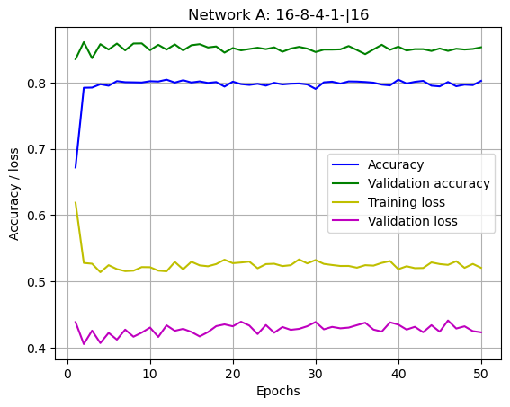

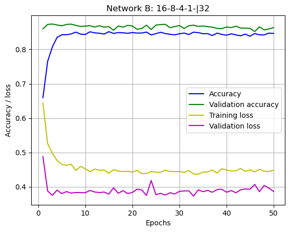

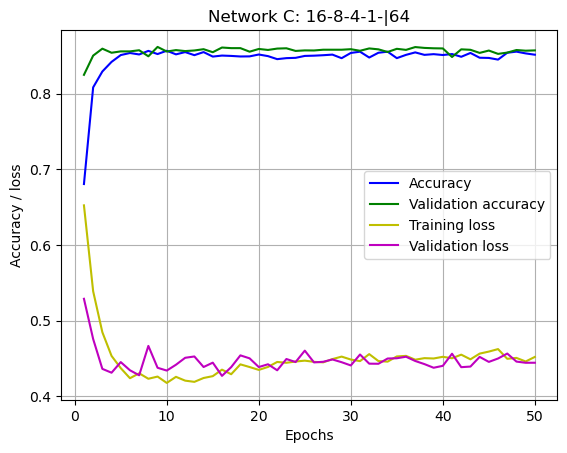

```python
#declare networks according to "histories[model_name]"
net_a, net_b, net_c = '16-8-4-1-|16', '16-8-4-1-|32', '16-8-4-1-|64'

plot_net_a(acc=histories[net_a].history['accuracy'], label_a="Accuracy",
           val_acc=histories[net_a].history['val_accuracy'], label_b="Validation accuracy",
            tloss=histories[net_a].history['loss'], label_c="Training loss",
            loss=histories[net_a].history['val_loss'], label_d="Validation loss", y_label='Accuracy / loss')
plot_net_b(acc=histories[net_b].history['accuracy'], label_a="Accuracy",
           val_acc=histories[net_b].history['val_accuracy'], label_b="Validation accuracy",
            tloss=histories[net_b].history['loss'], label_c="Training loss",
            loss=histories[net_b].history['val_loss'], label_d="Validation loss", y_label='Accuracy / loss')
plot_net_c(acc=histories[net_c].history['accuracy'], label_a="Accuracy",
            val_acc=histories[net_c].history['val_accuracy'], label_b="Validation accuracy",
            tloss=histories[net_c].history['loss'], label_c="Training loss",
            loss=histories[net_c].history['val_loss'], label_d="Validation loss", y_label='Accuracy / loss')
```

**Interpretation and best network candidate**

So far, it looks like net_c: 16-8-4-1-|64 is the best candidate so far. It exhibits good accuracy and the training and validation loss is stable and does not diverge even after 50 epochs.

## 8. Testing

Network net_c: 16-8-4-1-|64 is the best performing to solve the neural network solution. The network shows good accuracy for both training and validation, although not reaching 90%. When comparing the training and validation loss, we can see that both drops quickly and stabilizes without diverging.

So, we will save the parameters and retrain a new model for the optimal number of epochs and evaluate on the test data. From looking at the plots, we can see that around 7-10 epochs should be optimal.

### Setting parameters for model

```python
# define model Network net_c: 16-8-4-1-|64
model.reset_states()
model = models.Sequential()
model.add(layers.Dense(16, kernel_regularizer=regularizers.l2(0.001), activation='relu', input_shape=(10000,)))
model.add(layers.Dropout(0.4))
model.add(layers.Dense(8, kernel_regularizer=regularizers.l2(0.001), activation='relu'))
model.add(layers.Dropout(0.4))
model.add(layers.Dense(4, kernel_regularizer=regularizers.l2(0.001), activation='relu'))
model.add(layers.Dropout(0.4))
model.add(layers.Dense(1, activation='sigmoid'))
model.compile(optimizer='rmsprop',
    loss='binary_crossentropy',
    metrics=['accuracy'])
history = model.fit(x_train, y_train,
                    epochs=7,
                    batch_size=64,
                    verbose=0)
results = model.evaluate(x_test, y_test)
```

[output not shown]

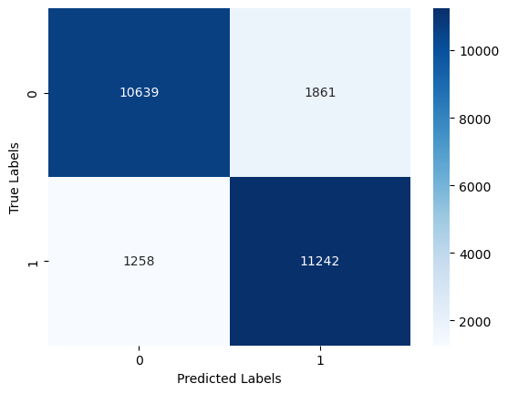

```python
#confusion matrix
y_pred = (model.predict(x_test)[:, 0] > 0.5).astype("int32")
conf_matrix = tf.math.confusion_matrix(labels=y_test, predictions=y_pred)
#SNS heatmap
sns.heatmap(conf_matrix, annot=True, cmap='Blues', fmt='d')
plt.xlabel('Predicted Labels')
plt.ylabel('True Labels')
plt.show()
```

```python
classification_report = classification_report(y_test, y_pred)
print(classification_report)
```

```
              precision    recall  f1-score   support

         0.0       0.89      0.85      0.87     12500
         1.0       0.86      0.90      0.88     12500

    accuracy                           0.88     25000
   macro avg       0.88      0.88      0.88     25000
weighted avg       0.88      0.88      0.88     25000
```

### Evaluation results

**Accuracy and loss:**

We can see that the accuracy achieved was 0.8752, with loss being 0.3723. This is much better than the baseline model we created in the beginning.

**Other performance metrics:**

After creating the confusion matrix with the tf.math.confusion_matrix and plotting it with SNS, we are able to visualize the performance. The Classification report also provided us with more metrics like precision, recall and f1-score.

Overall, these results are quite favorable, but it seems that the model is better at predicting positive movie reviews as seen in the 0.90 recall score.

But when looking at precision, positive scores worse as it is 0.86. This is due to the fact that there is a much higher number of false positives as seen in the confusion matrix (1861, top right). The precision for false labels performed better at 0.89 as the model predicted less false negatives.

F1-score is very similar for both positive and negative labels with only 0.01 difference.

### Plot accuracy and loss for training model

[figure not shown]

```python
#get history
history_dict = history.history
history_dict.keys()


# Let's plot training and validation accuracy as well as loss.
def plot_history(history):
    accuracy = history.history['accuracy']
    loss = history.history['loss']
    epochs = range(1,len(accuracy) + 1)
    # Plot accuracy
    plt.figure(1)
    plt.plot(epochs, accuracy, 'b', label='Training accuracy')
    plt.plot(epochs, loss, 'y', label='Training loss')
    plt.title('Training accuracy + Training loss')
    plt.xlabel('Epochs')
    plt.ylabel('Accuracy')
    plt.grid()
    plt.legend()
plot_history(history)
```

**Interpretation**

From looking at the plot, we can see that 7 epochs are a good choice for training the model and it is the peak for both accuracy and loss. It is not clear if adding more epochs will increase or decrease the performance of the model.

### Conclusion

The steps outline in the DLWP universal workflow of machine learning 4.5 has been followed. A baseline model was established then the model was expanded to create overfitting. Afterwards, the model was regularized and tuned with hyperparameters to find the best fitting model for the solution.